# R Notebook

```r
library(readxl)
df <- read_excel('/Users/jacopobinati/Desktop/thesis/Datasets/Data Finale_balanced1.xlsx')
```

## **1. Building the initial causal graph**

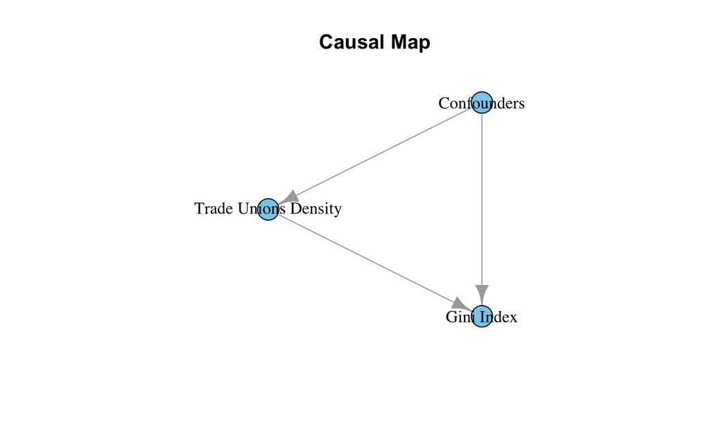

```r
library(igraph)
edges <- matrix(
  c('Trade Unions Density', 'Gini Index',
    'Confounders', 'Trade Unions Density',
    'Confounders', 'Gini Index'),
  ncol = 2, byrow = TRUE
)

P <- graph_from_edgelist(edges, directed = TRUE)

# Assign oval shape to vertex labels
V(P)$label_shape <- "ellipse"

# Plot
plot(
  P, layout = layout_with_sugiyama(P), vertex.size = 20, vertex.label = V(P)$name,
  vertex.color = 'skyblue', edge.arrow.size = 1, main = "Causal Map",
  font.main = 2, cex.main = 1.5, vertex.label.cex = 1, vertex.label.family = "Times",
  vertex.label.color = "black", margin = -0
)
```

The causal map illustrates a proposed relationship between ‘Trade Unions Density’ and ‘Gini Index’, indicated by an arrow pointing from ‘Trade Unions Density’ to ‘Gini Index’. This suggests that variations in trade unions density may lead to changes in the Gini index, implying a causal link between the two variables.

Additionally, ‘Confounders’ are linked to both ‘Trade Unions Density’ and ‘Gini Index’, implying that these external factors could influence both variables. However, without specific details about these confounders, their precise role in the causal relationship remains unclear.

## **1.1 Building the full causal graph**

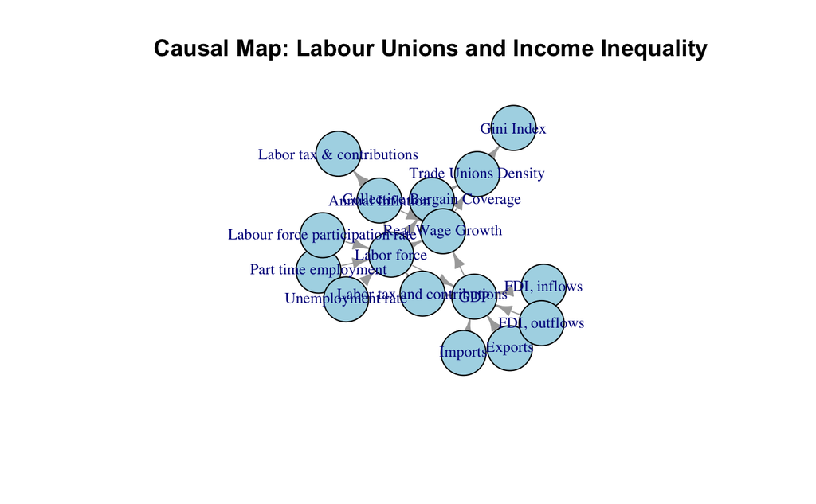

```r
set.seed(123)
nodes_with_categories <- data.frame(
  name = c('Collective Bargain Coverage', 'Trade Unions Density', 'Gini Index',
           'Real Wage Growth', 'Annual Inflation',
           'Exports',
           'Foreign direct investment, inflows',
           'Foreign direct investment, outflows',
           'Imports',
           'Current health expenditure',
           'Central government debt',
           'GDP',
           'Labour force participation rate',
           'Unemployment rate', 'Labor force, total',
           'Labor tax and contributions',
           'Part time employment, total', 'Monthly Minimum Wage'),
  category = c(rep('Collective Bargaining', 2), 'Income Inequality', rep('Economic', 11),
               rep('Labor Market', 4))
)
edges <- matrix(c('Trade Unions Density', 'Gini Index',
                  'Collective Bargain Coverage', 'Trade Unions Density',
                  'Real Wage Growth', 'Trade Unions Density',
                  'Annual Inflation', 'Real Wage Growth',
                  'Annual Inflation', 'Labor tax & contributions',
                  'Labor tax and contributions', 'GDP',
                  'Labor tax and contributions', 'Labor force',
                  'Part time employment', 'Labor force',
                  'Labour force participation rate', 'Labor force',
                  'Unemployment rate', 'Labor force',
                  'Labor force', 'Real Wage Growth',
                  'Labor force', 'Annual Inflation',
                  'Labor force', 'Collective Bargain Coverage',
                  'Labor force', 'GDP',
                  'GDP', 'Real Wage Growth',
                  'Exports', 'GDP',
                  'FDI, inflows', 'GDP',
                  'FDI, outflows', 'GDP',
                  'Imports', 'GDP'),
                byrow = TRUE, ncol = 2)

G <- graph_from_edgelist(edges, directed = TRUE)
V(G)$category <- nodes_with_categories$category[match(V(G)$name, nodes_with_categories$name)]

c <- plot(G,
          layout=layout_with_fr(G),
          vertex.size=40,
          vertex.label=V(G)$name,
          vertex.color="lightblue",
          main="Causal Map: Labour Unions and Income Inequality",
          edge.arrow.size=.7,
          vertex.label.cex=0.8,
          vertex.label.family="Times")
```

```r
# Save the plot
library(ggplot2)
ggsave(filename = "/Users/jacopobinati/Desktop/thesis/Images/fullcausalmap.png", plot = c, width = 10, height = 6)
```

## **2. Data processing and variable renaming**

```r
library(tidyr)
```

```r
library(dplyr)
```

```r
library(tibble)
df <- as_tibble(df)
```

```r
df <- df %>%
  rename(
    Labor_force = `Labor force, total`,
    GDP = `GDP (current US$)`,
    Inflation = `Annual Inflation CPI`,
    WageGrowth = `Real Average Annual Wage Growth`,
    Female_Workers = `Labour force participation rate (Women age 15 to 64)`,
    TradeUnions_Density = `TradeUnions_Density`, # Ensure case sensitivity matches your original dataframe
    Gov_debt = `Central government debt, total (% of GDP)`,
    WomenUnemployment_rate = `Unemployment rate (Women age 15 to 64)`,
    Health_expenditure = `Current health expenditure (% of GDP)`,
    Exports_growth = `Exports of goods and services (annual % growth)`,
    Imports_growth = `Imports of goods and services (% of GDP)`,
    FDI_inflow = `Foreign direct investment, net inflows (% of GDP)`,
    FDI_outflow = `Foreign direct investment, net outflows (% of GDP)`,
    Tax_contribution = `Labor tax and contributions (% of commercial profits)`,
    Parttime_employment = `Part time employment, total (% of total employment)`,
    Monthly_Minimum_Wage = `Monthly Minimum Wage`,
    Gini_Index = `Gini Index`,
  )
```

```r
rownames(df) <- NULL
```

```r
df <- df %>%
  mutate(lnGDP = round(log(GDP), 2))
# Create a binary column 'minwage' where 1 indicates there's at least one positive value in 'Monthly Minimum Wage'
# and 0 otherwise
df <- df %>%
  mutate(minwage = ifelse(Monthly_Minimum_Wage > 0, 1, 0))
df <- df %>%
  mutate(lnminwage = ifelse(Monthly_Minimum_Wage > 0, round(log(Monthly_Minimum_Wage), 2), 0))
df <- df %>%
  mutate(ln_labor = ifelse(Labor_force > 0, round(log(Labor_force), 2), 0))
# print Minimum_Monthly_Wage, minwage and lnminwage
print(df %>%
        select(Monthly_Minimum_Wage, minwage, lnminwage),
      n = Inf)
```

| Monthly_Minimum_Wage | minwage | lnminwage |
| --- | --- | --- |
| 0.00 | 0 | 0.00 |
| 0.00 | 0 | 0.00 |
| 0.00 | 0 | 0.00 |
| 0.00 | 0 | 0.00 |
| 0.00 | 0 | 0.00 |
| 0.00 | 0 | 0.00 |
| 0.00 | 0 | 0.00 |
| 0.00 | 0 | 0.00 |
| 0.00 | 0 | 0.00 |
| 0.00 | 0 | 0.00 |

[output cut: 782 more lines]

```r
first_year_positive_lnminwage <- df %>%
  filter(lnminwage > 0) %>%
  group_by(Country) %>%
  summarize(FirstYear = min(Year))

# create a new variable bargain
df <- df %>%
  mutate(bargain = TradeUnions_Density/CollectiveBargain_Coverage)
df <- df %>%
  mutate(unions = sqrt(TradeUnions_Density) * log(CollectiveBargain_Coverage))
df$Year <- as.numeric(as.character(df$Year))


# Calculate the average Gini index for each year
average_gini <- aggregate(Gini_Index ~ Year, data = df, FUN = mean)
average_trade_union <- aggregate(TradeUnions_Density ~ Year, data = df, FUN = mean)
average_collective_bargaining <- aggregate(CollectiveBargain_Coverage ~ Year, data = df, FUN = mean)
```

Why unions computed this way?

Nonlinear transformation, potentially capturing complex relationships between them# Enhanced Interpretability: The transformed variable “unions” could potentially have a more interpretable relationship with the original variables. For example, the square root transformation may help to stabilize variance, while the logarithmic transformation may compress larger values, making the relationship easier to understand or visualize.

```r
sapply(df, function(x) sum(is.na(x)) / length(x))
```

```
                        Country                            Year            Monthly_Minimum_Wage
                              0                               0                               0
     CollectiveBargain_Coverage             TradeUnions_Density                      WageGrowth
                              0                               0                               0
                      Inflation                      Gini_Index                  Female_Workers
                              0                               0                               0
         WomenUnemployment_rate                        Gov_debt Children out of school, primary
                              0                               0                               0
             Health_expenditure                  Exports_growth                      FDI_inflow
                              0                               0                               0
                    FDI_outflow                  Imports_growth                     Labor_force
                              0                               0                               0
               Tax_contribution             Parttime_employment                             GDP
                              0                               0                               0
                          lnGDP                         minwage                       lnminwage
                              0                               0                               0
                       ln_labor                         bargain                          unions
                              0                               0                               0
```

## 3. New Database implemented for Democratic Governance

ASSUME THAT CIVIC PARTICIPATION IS EXOGENOUS TO GINI INDEX

```r
library(readr)
rol <- read_csv("/Users/jacopobinati/Desktop/thesis/Datasets/rule-of-law-index.csv")
part <- read_csv("/Users/jacopobinati/Desktop/thesis/Datasets/civil-society-participation-index.csv")
# Specify countries to keep
countries_to_keep <- c('Austria', 'Belgium', 'Czechia', 'Denmark', 'Estonia', 'Finland',
                       'France', 'Germany', 'Greece', 'Hungary', 'Iceland', 'Ireland',
                       'Italy', 'Lithuania', 'Luxemburg', 'Netherlands', 'Norway', 'Poland',
                       'Portugal', 'Slovak Republic', 'Spain', 'Sweden', 'Switzerland',
                       'United Kingdom')

# Filter rol and part data
rol <- rol %>%
  filter(Year >= 1990, Entity %in% countries_to_keep)

part <- part %>%
  filter(Year >= 1990, Entity %in% countries_to_keep)

# Drop columns
columns_to_drop1 <- c('civsoc_particip_vdem_low_owid', 'civsoc_particip_vdem_high_owid')
columns_to_drop2 <- c('rule_of_law_vdem_low_owid', 'rule_of_law_vdem_high_owid')

rol <- select(rol, -one_of(columns_to_drop2))
part <- select(part, -one_of(columns_to_drop1))

# Rename columns
rol <- rename(rol, rol = rule_of_law_vdem_owid, Country = Entity)
part <- rename(part, civsoc_particip = civsoc_particip_vdem_owid, Country = Entity)
# merging process
df <- merge(df, rol, by = c("Country", "Year"), all.x = TRUE)
df <- merge(df, part, by = c("Country", "Year"), all.x = TRUE)

# Drop unnecessary columns
dropdf <- c('Code.x', 'Code.y')
df <- select(df, -one_of(dropdf))

# Create a new column 'demo'
df$demo <- df$civsoc_particip * df$rol
# create a copy of df and call it dataset
dataset <- df

# Check for missing values in the dataset
missing_values <- is.na(dataset)
missing_values_summary <- colSums(missing_values)
print(missing_values_summary)
```

```
                        Country                            Year            Monthly_Minimum_Wage
                              0                               0                               0
     CollectiveBargain_Coverage             TradeUnions_Density                      WageGrowth
                              0                               0                               0
                      Inflation                      Gini_Index                  Female_Workers
                              0                               0                               0
         WomenUnemployment_rate                        Gov_debt Children out of school, primary
                              0                               0                               0
             Health_expenditure                  Exports_growth                      FDI_inflow
                              0                               0                               0
                    FDI_outflow                  Imports_growth                     Labor_force
                              0                               0                               0
               Tax_contribution             Parttime_employment                             GDP
                              0                               0                               0
                          lnGDP                         minwage                       lnminwage
                              0                               0                               0
                       ln_labor                         bargain                          unions
                              0                               0                               0
                            rol                 civsoc_particip                            demo
                             66                              66                              66
```

```r
dataset <- dataset %>%
  filter(!Country %in% c("Slovak Republic", "Luxembourg"))
```

```r
dataset$net_export <- dataset$Exports_growth - dataset$Imports_growth
dataset$net_FDI <- dataset$FDI_inflow - dataset$FDI_outflow
```

```r
average_demo <- aggregate(demo ~ Year, data = dataset, FUN = mean)
average_civicsoc_particip <- aggregate(civsoc_particip ~ Year, data = dataset, FUN = mean)
average_rol <- aggregate(rol ~ Year, data = dataset, FUN = mean)
```

```r
# Calculate the normalized density and demo variables
dataset$norm_density <- (dataset$TradeUnions_Density - min(dataset$TradeUnions_Density)) / (max(dataset$TradeUnions_Density) - min(dataset$TradeUnions_Density))
dataset$norm_demo <- (dataset$demo - min(dataset$demo)) / (max(dataset$demo) - min(dataset$demo))

average_norm_density <- aggregate(norm_density ~ Year, data = dataset, FUN = mean)
average_norm_demo <- aggregate(norm_demo ~ Year, data = dataset, FUN = mean)
```

```r
# Ensure 'Year' and 'Country' are correctly formatted
dataset$Year <- as.integer(dataset$Year)
dataset$Country <- as.factor(dataset$Country)
##########################################################
# Sum of NA values in each column
na_count <- sapply(dataset, function(x) sum(is.na(x)))
print(na_count)
```

```
                        Country                            Year            Monthly_Minimum_Wage
                              0                               0                               0
     CollectiveBargain_Coverage             TradeUnions_Density                      WageGrowth
                              0                               0                               0
                      Inflation                      Gini_Index                  Female_Workers
                              0                               0                               0
         WomenUnemployment_rate                        Gov_debt Children out of school, primary
                              0                               0                               0
             Health_expenditure                  Exports_growth                      FDI_inflow
                              0                               0                               0
                    FDI_outflow                  Imports_growth                     Labor_force
                              0                               0                               0
               Tax_contribution             Parttime_employment                             GDP
                              0                               0                               0
                          lnGDP                         minwage                       lnminwage
                              0                               0                               0
                       ln_labor                         bargain                          unions
                              0                               0                               0
                            rol                 civsoc_particip                            demo
                              0                               0                               0
                     net_export                         net_FDI                    norm_density
                              0                               0                               0
                      norm_demo
                              0
```

```r
# Sum of infinite values in each column
inf_count <- sapply(dataset, function(x) sum(is.infinite(x)))
print(inf_count)
```

```
                        Country                            Year            Monthly_Minimum_Wage
                              0                               0                               0
     CollectiveBargain_Coverage             TradeUnions_Density                      WageGrowth
                              0                               0                               0
                      Inflation                      Gini_Index                  Female_Workers
                              0                               0                               0
         WomenUnemployment_rate                        Gov_debt Children out of school, primary
                              0                               0                               0
             Health_expenditure                  Exports_growth                      FDI_inflow
                              0                               0                               0
                    FDI_outflow                  Imports_growth                     Labor_force
                              0                               0                               0
               Tax_contribution             Parttime_employment                             GDP
                              0                               0                               0
                          lnGDP                         minwage                       lnminwage
                              0                               0                               0
                       ln_labor                         bargain                          unions
                              0                               0                               0
                            rol                 civsoc_particip                            demo
                              0                               0                               0
                     net_export                         net_FDI                    norm_density
                              0                               0                               0
                      norm_demo
                              0
```

```r
# Combined check for any NA or infinite values across the entire dataset
total_issues <- sum(na_count + inf_count)
print(total_issues)
```

```
[1] 0
```

## 4. Density and Coverage linear or non linear relationship?

```r
# plot TradeUnions_Density and CollectiveBargain_Coverage to understand if the relationship is linear or not
ggplot(dataset, aes(x = TradeUnions_Density, y = CollectiveBargain_Coverage)) +
  geom_point(alpha = 0.5) +
  geom_smooth(method = "lm", color = "blue", se = FALSE) + # Linear fit
  geom_smooth(method = "loess", color = "red", se = FALSE) + # Non-linear fit
  labs(title = 'Trade Unions Density vs Collective Bargaining Coverage',
       x = 'Trade Unions Density',
       y = 'Collective Bargaining Coverage') +
  theme_minimal()
```

[output not shown]

```r
library(plm)
# Fit linear and non-linear models using plm
# Define the panel data structure
pdata <- pdata.frame(dataset, index = c("Country", "Year"))
# Fit a linear model
linear_model <- plm(CollectiveBargain_Coverage ~ TradeUnions_Density, data = pdata, model = "within")
# Summarize the models
summary(linear_model)
```

[output not shown]

```r
# Fit a non-linear model (e.g., quadratic term)
non_linear_model <- plm(CollectiveBargain_Coverage ~ TradeUnions_Density + I(TradeUnions_Density^2), data = pdata, model = "within")
summary(non_linear_model)
```

[output not shown]

```r
# Manual AIC and BIC calculations
n <- nrow(dataset) # number of observations

# Linear model
rss_linear <- sum(residuals(linear_model)^2)
k_linear <- length(coef(linear_model))
aic_linear <- n * log(rss_linear / n) + 2 * k_linear
bic_linear <- n * log(rss_linear / n) + log(n) * k_linear

# Non-linear model
rss_non_linear <- sum(residuals(non_linear_model)^2)
k_non_linear <- length(coef(non_linear_model))
aic_non_linear <- n * log(rss_non_linear / n) + 2 * k_non_linear
bic_non_linear <- n * log(rss_non_linear / n) + log(n) * k_non_linear

# Compare AIC and BIC
aic_linear
aic_non_linear
bic_linear
bic_non_linear

# Print the results
cat("Linear Model: AIC =", aic_linear, "BIC =", bic_linear, "\n")
cat("Non-linear Model: AIC =", aic_non_linear, "BIC =", bic_non_linear, "\n")
```

[output not shown]

```r
# Plot residuals for the linear model
ggplot(dataset, aes(x = TradeUnions_Density, y = residuals(linear_model))) +
  geom_point(alpha = 0.5) +
  geom_smooth(method = "loess", color = "red", se = FALSE) +
  labs(title = 'Residuals of Linear Model',
       x = 'Trade Unions Density',
       y = 'Residuals') +
  theme_minimal()

# Plot residuals for the non-linear model
ggplot(dataset, aes(x = TradeUnions_Density, y = residuals(non_linear_model))) +
  geom_point(alpha = 0.5) +
  geom_smooth(method = "loess", color = "red", se = FALSE) +
  labs(title = 'Residuals of Non-linear Model',
       x = 'Trade Unions Density',
       y = 'Residuals') +
  theme_minimal()
```

[output not shown]

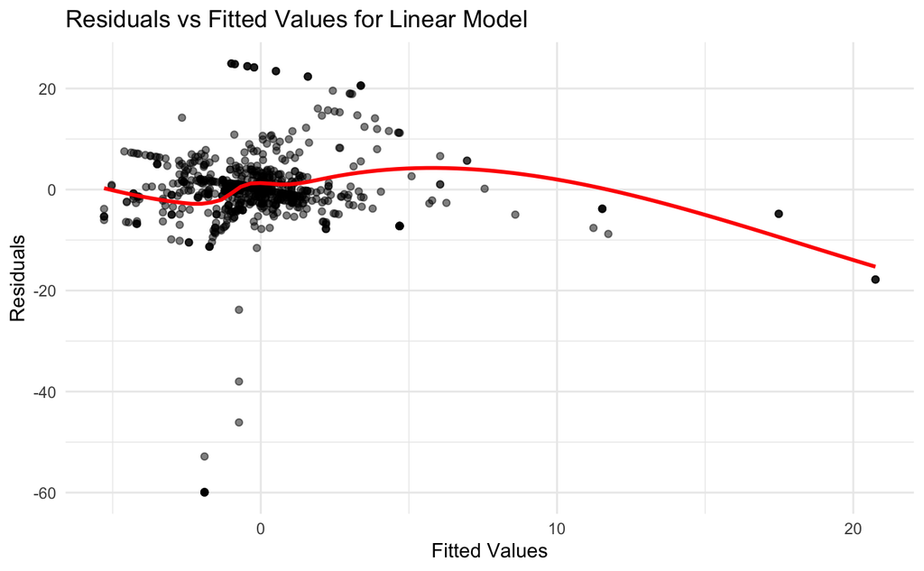

```r
# Extract fitted values and residuals
dataset$fitted_linear <- fitted(linear_model)
dataset$residuals_linear <- residuals(linear_model)
dataset$fitted_non_linear <- fitted(non_linear_model)
dataset$residuals_non_linear <- residuals(non_linear_model)

# Residuals vs Fitted for Linear Model
ggplot(dataset, aes(x = fitted_linear, y = residuals_linear)) +
  geom_point(alpha = 0.5) +
  geom_smooth(method = "loess", color = "red", se = FALSE) +
  labs(title = 'Residuals vs Fitted Values for Linear Model',
       x = 'Fitted Values',
       y = 'Residuals') +
  theme_minimal()
```

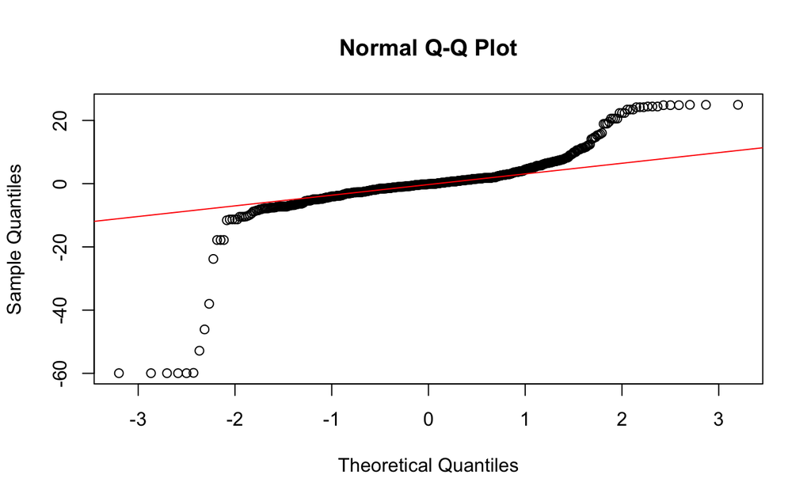

```r
# Q-Q Plot for Linear Model Residuals
qqnorm(dataset$residuals_linear)
qqline(dataset$residuals_linear, col = "red")
```

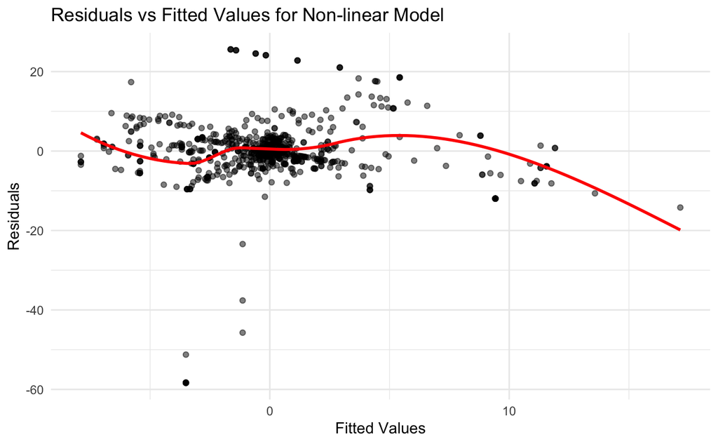

```r
# Residuals vs Fitted for Non-linear Model
ggplot(dataset, aes(x = fitted_non_linear, y = residuals_non_linear)) +
  geom_point(alpha = 0.5) +
  geom_smooth(method = "loess", color = "red", se = FALSE) +
  labs(title = 'Residuals vs Fitted Values for Non-linear Model',
       x = 'Fitted Values',
       y = 'Residuals') +
  theme_minimal()
```

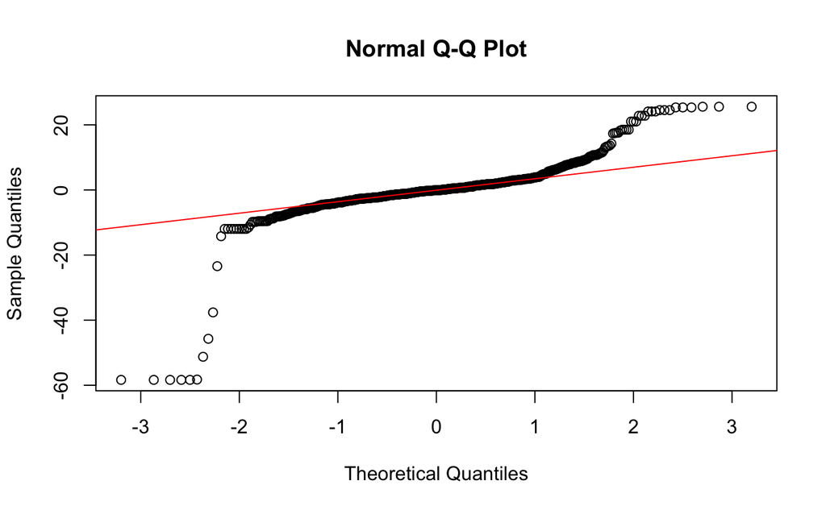

```r
# Q-Q Plot for Non-linear Model Residuals
qqnorm(dataset$residuals_non_linear)
qqline(dataset$residuals_non_linear, col = "red")
```

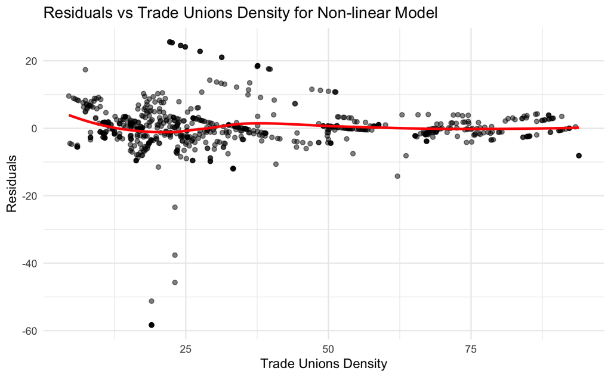

```r
# Residuals vs Trade Unions Density for Non-linear Model
ggplot(dataset, aes(x = TradeUnions_Density, y = residuals_non_linear)) +
  geom_point(alpha = 0.5) +
  geom_smooth(method = "loess", color = "red", se = FALSE) +
  labs(title = 'Residuals vs Trade Unions Density for Non-linear Model',
       x = 'Trade Unions Density',
       y = 'Residuals') +
  theme_minimal()
```

#### 4.1 New variable creation: unions

```r
df <- df %>%
  mutate(unions = sqrt(TradeUnions_Density) * log(CollectiveBargain_Coverage))
```

## **5. Plots**

```r
library(ggplot2)
```

```r
# make long dataset: df_long
df_long <- pivot_longer(dataset,
                        cols = -c(Country, Year),
                        names_to = "Variable",
                        values_to = "Value")
```

```r
YearIntroduced <- df_long %>%
  group_by(Country) %>%
  filter(Variable == "lnminwage" & Value > 0) %>%
  slice(1) %>%
  ungroup()
YearIntroduced <- dataset %>%
  group_by(Country) %>%
  mutate(YearIntroduced = ifelse(lnminwage > 0, 1, 0))
```

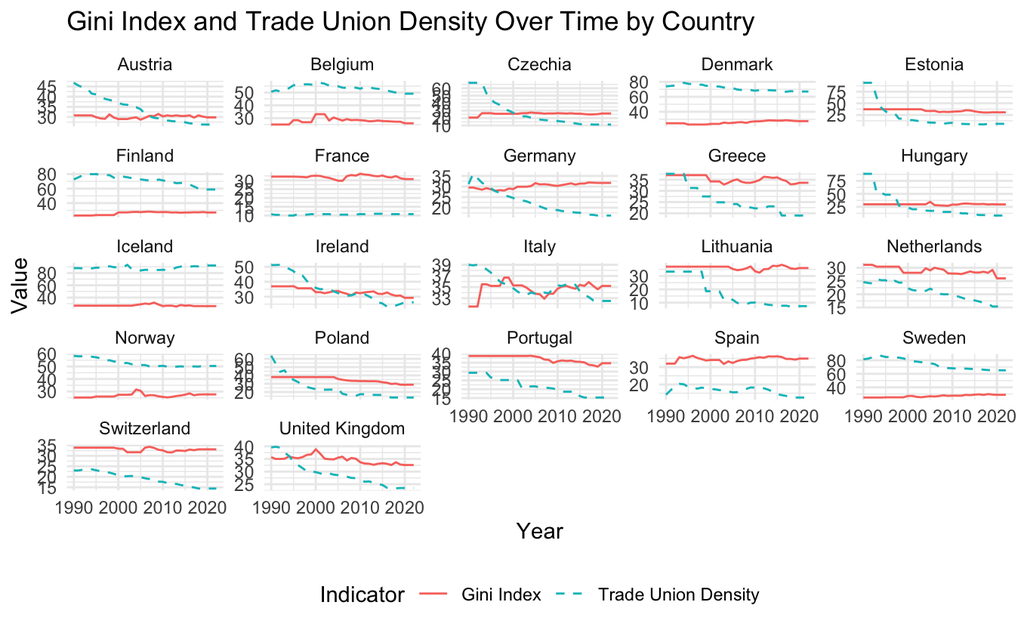

```r
# Plot with YearIntroduced
b <- ggplot(dataset, aes(x = Year)) +
  geom_line(aes(y = Gini_Index, color = "Gini Index"), linetype = "solid") +
  geom_line(aes(y = TradeUnions_Density, color = "Trade Union Density"), linetype = "dashed") +
  facet_wrap(~ Country, scales = "free_y", nrow = 5) +
  labs(title = "Gini Index and Trade Union Density Over Time by Country",
       y = "Value",
       x = "Year",
       color = "Indicator") +
  theme_minimal() +
  theme(legend.position = "bottom")
b
```

```r
# Save the plot
ggsave(filename = "/Users/jacopobinati/Desktop/thesis/Images/evolutionGini&Density.png", plot = b, width = 10, height = 6)
```

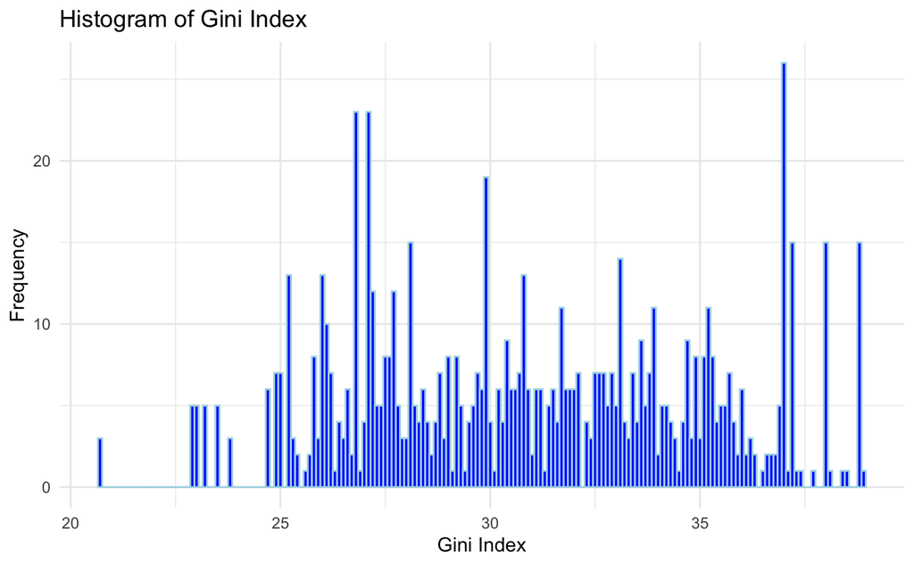

```r
# Plotting the histogram for Gini_Index
ggplot(df, aes(x = Gini_Index)) +
  geom_histogram(binwidth = 0.1, fill = "blue", color = "lightblue") +
  ggtitle("Histogram of Gini Index") +
  xlab("Gini Index") +
  ylab("Frequency") +
  theme_minimal()
```

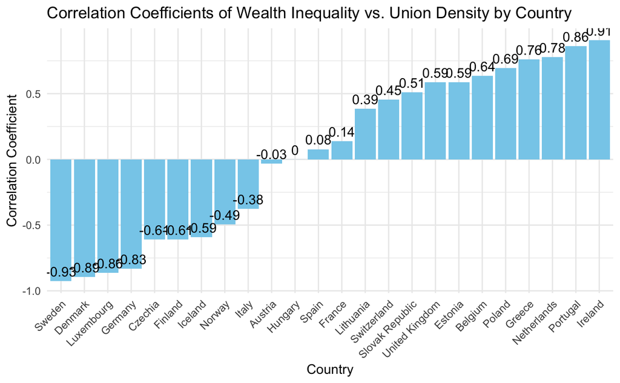

```r
# Correlation Coefficients of Wealth Inequality vs. Union Density forEach Country IndividuallyUnion
correlation_df <- df %>%
  group_by(Country) %>%
  summarize(correlation = cor(Gini_Index, TradeUnions_Density, use = "pairwise.complete.obs"))
correlation_df$Country <- factor(correlation_df$Country, levels = correlation_df$Country[order(correlation_df$correlation)])

ggplot(correlation_df, aes(x = Country, y = correlation)) +
  geom_bar(stat = "identity", fill = "skyblue", position = "dodge") +
  geom_text(aes(label = round(correlation, 2)), vjust = -0.5, position = position_dodge(width = 0.7)) +
  ggtitle("Correlation Coefficients of Wealth Inequality vs. Union Density by Country") +
  xlab("Country") +
  ylab("Correlation Coefficient") +
  theme_minimal() +
  theme(axis.text.x = element_text(angle = 45, hjust = 1))
```

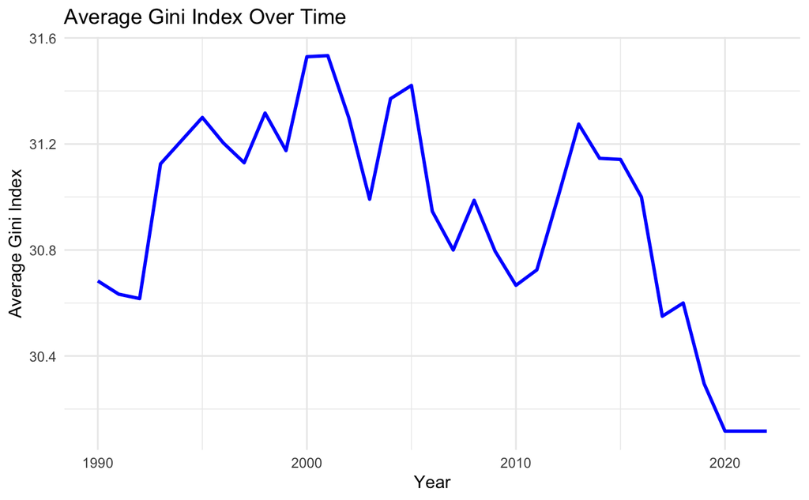

```r
# Plotting the scatter of average Gini index, Trade union density, and collective brgaining over time
# First plot: Average Gini Index over time
ggplot(average_gini, aes(x = Year, y = Gini_Index)) +
  geom_line(color = "blue", size = 1) +
  labs(title = "Average Gini Index Over Time",
       x = "Year",
       y = "Average Gini Index") +
  theme_minimal()
```

```r
# Second plot: Average Trade Union Density and Collective Bargaining Coverage over time
p <- ggplot() +
  geom_line(data = average_trade_union, aes(x = Year, y = TradeUnions_Density, color = "Trade Union Density"), size = 1) +
  geom_line(data = average_collective_bargaining, aes(x = Year, y = CollectiveBargain_Coverage, color = "Collective Bargaining Coverage"), size = 1) +
  labs(title = "Average Union Density and Bargaining Coverage Over Time",
       x = "Year",
       y = "Average",
       color = "Variable") +
  scale_color_manual(values = c("lightblue", "lightgreen"),
                     labels = c("Collective Bargaining Coverage", "Trade Union Density")) +
  theme_minimal() +
  theme(legend.position = "bottom",
        text = element_text(size = 16),
        legend.text = element_text(size = 20),
        legend.title = element_text(size = 20),
        plot.title = element_text(size = 24),
        axis.text.x = element_text(angle = 45, hjust = 1)) + # rotate x-axis labels
  ylim(20, 80)
```

```r
# Save the plot
ggsave(filename = "/Users/jacopobinati/Desktop/thesis/Images/averageovertime.png", plot = p, width = 10, height = 6)
```

```r
j <- ggplot(dataset, aes(x = Year)) +
    geom_line(aes(y = WomenUnemployment_rate, color = "Women Unemployment Rate"), linetype = "solid") +
    geom_line(aes(y = TradeUnions_Density, color = "Trade Unions Density"), linetype = "dashed") +
    facet_wrap(~ Country, scales = "free_y", nrow = 5) +
    labs(title = "Women Unemployment Rate and Trade Unions Density Over Time",
         y = "Value",
         x = "Year",
         color = "Variable") +
    theme_minimal() +
    theme(legend.position = "bottom")
ggsave(filename = "/Users/jacopobinati/Desktop/thesis/Images/womenunemploy_density.png", plot = j, width = 10, height = 6)
```

#### 4.2 K-means clustering and plotting

Why this? this shows how coverage and density spread over time for each country. what’s meaningful is to see that a perfect proportion would follow the red line but in most of the cases we find high coverage and low density, showing low protection of workers from trade unions.

```r
# Perform k-means clustering
set.seed(123) # for reproducibility
kmeans_result <- kmeans(df[, c("TradeUnions_Density", "CollectiveBargain_Coverage")],
                        centers = 3)

# Add cluster labels to the dataframe
df$cluster <- as.factor(kmeans_result$cluster)

# Scatter plot with k-means clustering
g <- ggplot(df, aes(x = TradeUnions_Density, y = CollectiveBargain_Coverage, color = cluster)) +
  geom_point(alpha = 0.7) +
  geom_abline(slope = 1, intercept = 0, linetype = "dashed", color = "red") +
  coord_cartesian(xlim = c(0, 100), ylim = c(0, 100)) +
  theme_minimal() +
  labs(
    title = "Scatter Plot of Trade Union Density vs. Collective Bargain Coverage with K-means Clustering",
    x = "Trade Union Density (%)",
    y = "Collective Bargain Coverage (%)",
    color = "Cluster"
  ) +
  theme(
    plot.title = element_text(hjust = 0.5),
    legend.position = "bottom"
  )
# Save the plot
ggsave(filename = "/Users/jacopobinati/Desktop/thesis/Images/kmeanclustering_densityCoverage.png", plot = g, width = 10, height = 6)
```

#### 4.3 Plot the average values of demo, civsoc_particip, and rol over time

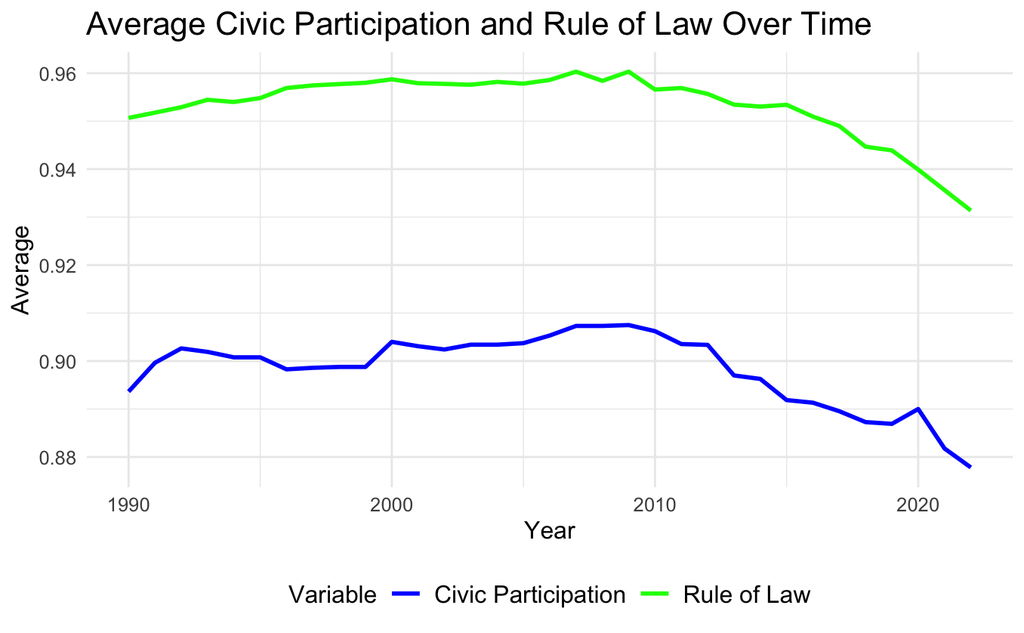

```r
ggplot() +
  geom_line(data = average_civicsoc_particip, aes(x = Year, y = civsoc_particip, color = "Civic Participation"), size = 1) +
  geom_line(data = average_rol, aes(x = Year, y = rol, color = "Rule of Law"), size = 1) +
  labs(title = "Average Civic Participation and Rule of Law Over Time",
       x = "Year",
       y = "Average",
       color = "Variable") +
  scale_color_manual(values = c("blue", "green"),
                     labels = c("Civic Participation", "Rule of Law"),
                     name = "Variable") +
  theme_minimal() +
  theme(legend.position = "bottom",
        text = element_text(size = 12),
        legend.text = element_text(size = 12),
        legend.title = element_text(size = 12),
        plot.title = element_text(size = 16))
```

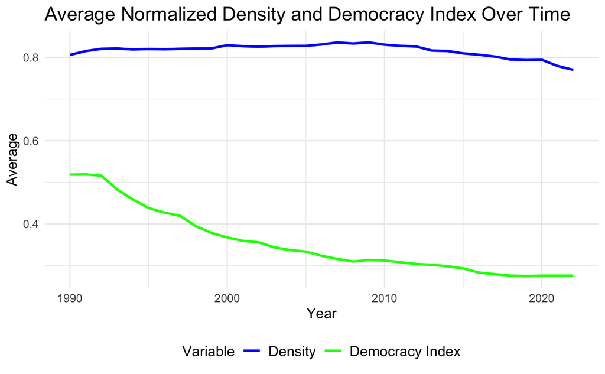

```r
ggplot() +
  geom_line(data = average_norm_density, aes(x = Year, y = norm_density, color = "Density"), size = 1) +
  geom_line(data = average_norm_demo, aes(x = Year, y = norm_demo, color = "Democracy Index"), size = 1) +
  labs(title = "Average Normalized Density and Democracy Index Over Time",
       x = "Year",
       y = "Average",
       color = "Variable") +
  scale_color_manual(values = c("blue", "green"),
                     labels = c("Density", "Democracy Index")) +
  theme_minimal() +
  theme(legend.position = "bottom",
        text = element_text(size = 12),
        legend.text = element_text(size = 12),
        legend.title = element_text(size = 12),
        plot.title = element_text(size = 16))
```

```r
plot_fdi <- ggplot(dataset, aes(x = Year)) +
  geom_line(aes(y = FDI_inflow, color = "FDI Inflow")) +
  geom_line(aes(y = FDI_outflow, color = "FDI Outflow")) +
  facet_wrap(~ Country, scales = "free_y") +
  labs(title = "FDI Inflow and FDI Outflow Over Time by Country",
       y = "Value",
       x = "Year",
       color = "Indicator") +
  theme_minimal() +
  theme(legend.position = "bottom")

# Plot for GDP over time
plot_gdp <- ggplot(dataset, aes(x = Year)) +
  geom_line(aes(y = lnGDP, color = "lnGDP")) +
  facet_wrap(~ Country, scales = "free_y") +
  labs(title = "Logarithm of GDP Over Time by Country",
       y = "ln(GDP)",
       x = "Year",
       color = "Indicator") +
  theme_minimal() +
  theme(legend.position = "bottom")

# Save the plots
ggsave(filename = "/Users/jacopobinati/Desktop/thesis/Images/FDI.png", plot = plot_fdi, width = 10, height = 6)
ggsave(filename = "/Users/jacopobinati/Desktop/thesis/Images/GDP.png", plot = plot_gdp, width = 10, height = 6)
```

```r
net <- ggplot(dataset, aes(x = Year)) +
  geom_line(aes(y = net_export, color = "Net Exports"), linetype = "solid") +
  geom_line(aes(y = net_FDI, color = "Net Foreign Direct Investments"), linetype = "dashed") +
  facet_wrap(~ Country, scales = "free_y", nrow = 5) +
  labs(title = "Net Exports and Net Foreign Direct Investments Over Time by Country",
       y = "Value",
       x = "Year",
       color = "Indicator") +
  theme_minimal() +
  theme(legend.position = "bottom")
ggsave(filename = "/Users/jacopobinati/Desktop/thesis/Images/netExportsFDI.png", plot = net, width = 10, height = 6)
```

## 5. Checking for Multicollinearity with Eigenvalue test and VIF

```r
library(xtable)
```

```r
# Check for multicollinearity using the eigenvalue test
correlation_matrix <- cor(dataset[, c("demo", "unions","CollectiveBargain_Coverage", "Inflation", "WageGrowth", "Gov_debt", "ln_labor", "WomenUnemployment_rate", "net_export", "net_FDI", "Tax_contribution")])
eigenvalues <- eigen(correlation_matrix)$values
print(eigenvalues)
```

```
 [1] 2.5726389 1.9822257 1.3341763 1.2146067 0.9742809 0.8375979 0.6898381 0.5757385 0.4088247 0.2448070 0.1652653
```

```r
# Check for multicollinearity using the VIF function
vif_values <- car::vif(lm(Gini_Index ~ demo + unions + CollectiveBargain_Coverage + Inflation + WageGrowth + Gov_debt + ln_labor + WomenUnemployment_rate + net_export + net_FDI + Tax_contribution, data = dataset))
```

```r
independent_vars <- c("demo", "unions", "CollectiveBargain_Coverage", "Inflation", "WageGrowth", "Gov_debt", "ln_labor", "WomenUnemployment_rate", "net_export", "net_FDI", "Tax_contribution")

vif_df <- data.frame(VIF = vif_values)
vif_df
```

|  | VIF |
| --- | --- |
| demo | 2.079719 |
| unions | 3.437280 |
| CollectiveBargain_Coverage | 2.922030 |
| Inflation | 1.113406 |
| WageGrowth | 1.284423 |
| Gov_debt | 1.274968 |
| ln_labor | 2.000497 |
| WomenUnemployment_rate | 1.607541 |
| net_export | 1.875840 |
| net_FDI | 1.158531 |

[output cut: 1 more lines]

The output shows the VIF values for each independent variable. VIF values below 5 are generally considered acceptable, indicating that multicollinearity is not severe. In this case, all VIF values are below 5, suggesting that multicollinearity is not a significant concern among the predictor variables in the model. However, it’s essential to interpret these results in conjunction with other diagnostics and consider the context of the analysis.

```r
library(xtable)
independent_vars <- c("Democratic Governance", "Trade Unions", "Collective Bargain Coverage", "Inflation", "Wage Growth", "Government Debt (%)", "Log of Labor participation", "Women Unemployment Rate", "Net Export", "Net FDI", "Tax Contribution")
# Create dataframe with eigenvalues and VIF values
eigen_vif_df <- data.frame(variables = independent_vars, Eigenvalue = eigenvalues, VIF = vif_values)

# Print the dataframe
print(eigen_vif_df)
```

|  | variables | Eigenvalue | VIF |
| --- | --- | --- | --- |
| demo | Democratic Governance | 2.5726389 | 2.079719 |
| unions | Trade Unions | 1.9822257 | 3.437280 |
| CollectiveBargain_Coverage | Collective Bargain Coverage | 1.3341763 | 2.922030 |
| Inflation | Inflation | 1.2146067 | 1.113406 |
| WageGrowth | Wage Growth | 0.9742809 | 1.284423 |
| Gov_debt | Government Debt (%) | 0.8375979 | 1.274968 |
| ln_labor | Log of Labor participation | 0.6898381 | 2.000497 |
| WomenUnemployment_rate | Women Unemployment Rate | 0.5757385 | 1.607541 |
| net_export | Net Export | 0.4088247 | 1.875840 |
| net_FDI | Net FDI | 0.2448070 | 1.158531 |

[output cut: 1 more lines]

```r
# Define the file path
file_path <- "/Users/jacopobinati/Desktop/thesis/results/VIF_Eigenvalue.tex"

# Write the dataframe to a text file
write.table(eigen_vif_df, file = file_path, sep = "\t", quote = FALSE, row.names = FALSE)
```

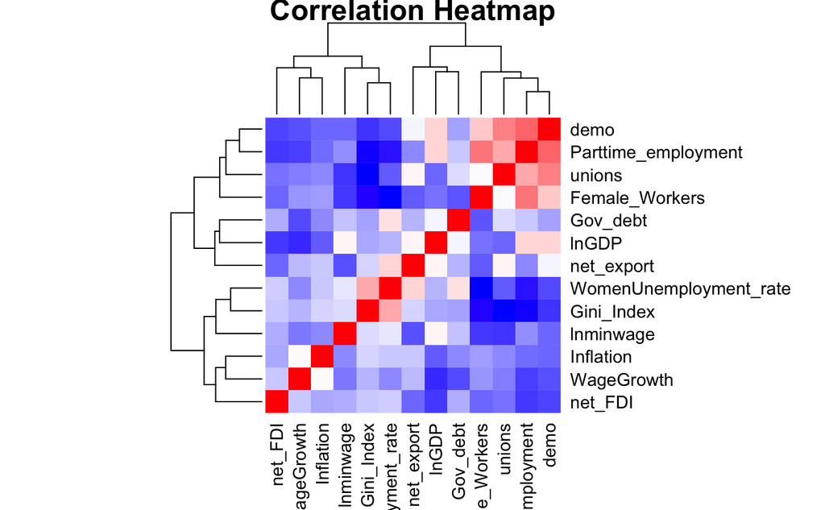

```r
variables <- dataset[, c("Gini_Index", "demo", "unions", "Inflation", "WageGrowth",
                         "Gov_debt", "lnminwage", "lnGDP",
                         "WomenUnemployment_rate",
                         "Female_Workers","Parttime_employment", "net_export", "net_FDI")]

# Calculating the correlation coefficients
correlation_matrix <- cor(variables)

# Plotting the heatmap
heatmap(correlation_matrix,
        col = colorRampPalette(c("blue", "white", "red"))(100),
        scale = "none",
        main = "Correlation Heatmap")
```

## 6. Model Building

```r
library(stargazer)
```

```r
library(plm)
```

```r
library(AER)
```

```r
library(readr)
df <- df %>%
  mutate(
    Country = as.factor(Country),
    Year = as.factor(Year)
  )
pdata <- pdata.frame(df, index = c("Country", "Year"))
```

Creating first models for OLS, FE, and FD:

```r
model_formulas <- c(
  "Gini_Index ~ TradeUnions_Density + unions + Inflation + WageGrowth + lnminwage",

  "Gini_Index ~ TradeUnions_Density + unions + Inflation + WageGrowth + lnminwage + CollectiveBargain_Coverage",

  "Gini_Index ~ TradeUnions_Density + unions + Inflation + WageGrowth + lnminwage + CollectiveBargain_Coverage + lnGDP + Gov_debt",

  "Gini_Index ~ TradeUnions_Density + unions + Inflation + WageGrowth + lnminwage + CollectiveBargain_Coverage + lnGDP + Gov_debt + ln_labor + Female_Workers + Parttime_employment + WomenUnemployment_rate",

  "Gini_Index ~ TradeUnions_Density + unions + Inflation + WageGrowth + lnminwage + CollectiveBargain_Coverage + lnGDP + Gov_debt + ln_labor + Female_Workers + Parttime_employment + WomenUnemployment_rate + net_export",

  "Gini_Index ~ TradeUnions_Density + unions + Inflation + WageGrowth + lnminwage + CollectiveBargain_Coverage + lnGDP + Gov_debt + ln_labor + Female_Workers + Parttime_employment + WomenUnemployment_rate + net_export + net_FDI + Tax_contribution"
)

create_models <- function(data, type, formulas) {
  lapply(formulas, function(formula) {
    formula <- as.formula(formula)
    if (type == "OLS") {
      return(lm(formula, data = dataset))
    } else if (type == "FE") {
      return(plm(formula, data = dataset, model = "within"))
    } else if (type == "FD") {
      return(plm(formula, data = dataset, model = "fd"))
    } else {
      stop("Unknown model type")
    }
  })
}

# Create OLS, FE, and FD models
ols_models <- create_models(df, "OLS", model_formulas)
fe_models <- create_models(pdata, "FE", model_formulas)
fd_models <- create_models(pdata, "FD", model_formulas)

# Summarize the models
stargazer(ols_models[c(4, 5, 6)], type = "text", title = "OLS Regression Models")
```

```
OLS Regression Models
=====================================================================================================
                                                      Dependent variable:
                           --------------------------------------------------------------------------
                                                           Gini_Index
                                     (1)                      (2)                      (3)
-----------------------------------------------------------------------------------------------------
TradeUnions_Density                -0.110**                -0.140***                  -0.058
                                   (0.043)                  (0.043)                  (0.045)

unions                              0.090                    0.140                    -0.108
                                   (0.122)                  (0.120)                  (0.127)

Inflation                          0.004**                  0.003**                   0.003*
                                   (0.002)                  (0.002)                  (0.002)

WageGrowth                         -0.064*                 -0.100***                 -0.085**
                                   (0.039)                  (0.038)                  (0.038)

lnminwage                          -0.094**                  -0.002                   -0.035
                                   (0.039)                  (0.041)                  (0.041)

CollectiveBargain_Coverage          -0.009                  -0.026**                  0.015
                                   (0.012)                  (0.012)                  (0.014)

lnGDP                             -1.026***                -0.784***                -1.076***
                                   (0.280)                  (0.278)                  (0.279)

Gov_debt                            0.003                    0.004                    0.004
                                   (0.003)                  (0.003)                  (0.003)

ln_labor                           0.948***                  0.227                   0.735**
                                   (0.303)                  (0.324)                  (0.332)

Female_Workers                      -0.026                  -0.041*                  -0.055**
                                   (0.023)                  (0.023)                  (0.022)

Parttime_employment                 -0.019                   -0.009                  -0.034**
                                   (0.017)                  (0.017)                  (0.017)

```

[output cut: 8 more lines]

```

Tax_contribution                                                                    -0.068***
                                                                                     (0.013)

Constant                          46.931***                55.580***                58.422***
                                   (3.355)                  (3.637)                  (3.629)

-----------------------------------------------------------------------------------------------------
Observations                         726                      726                      726
R2                                  0.451                    0.474                    0.495
Adjusted R2                         0.442                    0.464                    0.484
Residual Std. Error            3.047 (df = 713)         2.985 (df = 712)         2.929 (df = 710)
F Statistic                48.856*** (df = 12; 713) 49.358*** (df = 13; 712) 46.405*** (df = 15; 710)
=====================================================================================================
Note:                                                                     *p<0.1; **p<0.05; ***p<0.01
```

```r
stargazer(fd_models[c(4, 5, 6)], type = "text", title = "First Differences Regression Models")
```

```
First Differences Regression Models
===============================================================================================
                                                   Dependent variable:
                           --------------------------------------------------------------------
                                                        Gini_Index
                                    (1)                    (2)                    (3)
-----------------------------------------------------------------------------------------------
TradeUnions_Density               -0.096**               -0.097**               -0.096**
                                  (0.048)                (0.048)                (0.048)

unions                            0.378**                0.379**                0.377**
                                  (0.180)                (0.181)                (0.181)

Inflation                         0.00000                0.00000                0.00000
                                  (0.001)                (0.001)                (0.001)

WageGrowth                       -0.034***              -0.033***              -0.033***
                                  (0.012)                (0.012)                (0.012)

lnminwage                          -0.104                 -0.104                 -0.105
                                  (0.078)                (0.078)                (0.078)

CollectiveBargain_Coverage         -0.010                 -0.010                 -0.009
                                  (0.020)                (0.020)                (0.020)

lnGDP                              -0.291                 -0.286                 -0.270
                                  (0.399)                (0.402)                (0.402)

Gov_debt                           0.003                  0.003                  0.003
                                  (0.006)                (0.006)                (0.006)

ln_labor                           4.392                  4.378                  4.208
                                  (3.374)                (3.378)                (3.382)

Female_Workers                     -0.043                 -0.043                 -0.042
                                  (0.051)                (0.052)                (0.052)

Parttime_employment                0.003                  0.003                  0.003
                                  (0.011)                (0.011)                (0.011)

WomenUnemployment_rate             0.037                  0.038                  0.038
                                  (0.031)                (0.032)                (0.032)

net_export                                                -0.001                 -0.001
                                                         (0.004)                (0.004)

net_FDI                                                                          0.003
                                                                                (0.006)

Tax_contribution                                                                 -0.040
                                                                                (0.033)

Constant                           0.008                  0.008                  0.007
                                  (0.045)                (0.045)                (0.046)

-----------------------------------------------------------------------------------------------
Observations                        704                    704                    704
R2                                 0.036                  0.036                  0.038
Adjusted R2                        0.019                  0.018                  0.017
F Statistic                2.151** (df = 12; 691) 1.984** (df = 13; 690) 1.830** (df = 15; 688)
===============================================================================================
Note:                                                               *p<0.1; **p<0.05; ***p<0.01
```

```r
stargazer(fe_models[c(4, 5, 6)], type = "text", title = "Fixed Effects Regression Models")
```

```
Fixed Effects Regression Models
=====================================================================================================
                                                      Dependent variable:
                           --------------------------------------------------------------------------
                                                           Gini_Index
                                     (1)                      (2)                      (3)
-----------------------------------------------------------------------------------------------------
TradeUnions_Density               -0.353***                -0.353***                -0.355***
                                   (0.038)                  (0.038)                  (0.037)

unions                             1.162***                 1.183***                 1.206***
                                   (0.128)                  (0.127)                  (0.126)

Inflation                           0.001                    0.001                    0.001
                                   (0.001)                  (0.001)                  (0.001)

WageGrowth                         -0.035*                   -0.021                   -0.018
                                   (0.021)                  (0.021)                  (0.021)

lnminwage                         -0.181***                -0.189***                -0.163***
                                   (0.063)                  (0.063)                  (0.062)

CollectiveBargain_Coverage        -0.108***                -0.108***                -0.107***
                                   (0.016)                  (0.016)                  (0.016)

lnGDP                              -0.620**                -0.763***                 -0.666**
                                   (0.262)                  (0.265)                  (0.267)

Gov_debt                            -0.003                   -0.004                   -0.001
                                   (0.004)                  (0.004)                  (0.004)

ln_labor                           2.807**                  2.739**                  3.191***
                                   (1.215)                  (1.208)                  (1.201)

Female_Workers                      0.006                    -0.003                   -0.022
                                   (0.023)                  (0.023)                  (0.023)

Parttime_employment                0.057***                 0.055***                 0.053***
                                   (0.014)                  (0.014)                  (0.014)

WomenUnemployment_rate             0.062***                 0.079***                 0.088***
                                   (0.023)                  (0.023)                  (0.023)

net_export                                                 -0.025***                -0.024***
                                                            (0.008)                  (0.008)

net_FDI                                                                              -0.035**
                                                                                     (0.014)

Tax_contribution                                                                    -0.117***
                                                                                     (0.037)

-----------------------------------------------------------------------------------------------------
Observations                         726                      726                      726
R2                                  0.224                    0.235                    0.253
Adjusted R2                         0.187                    0.197                    0.214
F Statistic                16.664*** (df = 12; 692) 16.303*** (df = 13; 691) 15.592*** (df = 15; 689)
=====================================================================================================
Note:                                                                     *p<0.1; **p<0.05; ***p<0.01
```

```r
FE_summary <- summary(fd_models[c(4, 5, 6)])
FE_summary <- xtable(FE_summary)

file_path_FE <- "/Users/jacopobinati/Desktop/thesis/results/FE_table.tex"

# Print LaTeX tables to files
print(FE_summary, file = file_path_FE)
```

```r
library(Matrix)
library(lfe)
```

```r
library(lmtest)
first_stage <- lm(unions ~ demo + CollectiveBargain_Coverage + Inflation + WageGrowth + Gov_debt + ln_labor + WomenUnemployment_rate, data = dataset)
summary(first_stage)
```

```
Call:
lm(formula = unions ~ demo + CollectiveBargain_Coverage + Inflation +
    WageGrowth + Gov_debt + ln_labor + WomenUnemployment_rate,
    data = dataset)

Residuals:
     Min       1Q   Median       3Q      Max
-13.1177  -4.1478   0.4871   3.2921  18.7656

Coefficients:
                            Estimate Std. Error t value Pr(>|t|)
(Intercept)                35.102147   3.181095  11.035  < 2e-16 ***
demo                       23.023832   2.159244  10.663  < 2e-16 ***
CollectiveBargain_Coverage  0.182978   0.008767  20.872  < 2e-16 ***
Inflation                   0.008055   0.003013   2.673  0.00768 **
WageGrowth                  0.156345   0.070271   2.225  0.02640 *
Gov_debt                    0.033062   0.005699   5.802 9.85e-09 ***
ln_labor                   -2.860703   0.174913 -16.355  < 2e-16 ***
WomenUnemployment_rate     -0.185397   0.046108  -4.021 6.41e-05 ***
---
Signif. codes:  0 ‘***’ 0.001 ‘**’ 0.01 ‘*’ 0.05 ‘.’ 0.1 ‘ ’ 1

Residual standard error: 5.722 on 718 degrees of freedom
Multiple R-squared:  0.6596,    Adjusted R-squared:  0.6563
F-statistic: 198.8 on 7 and 718 DF,  p-value: < 2.2e-16
```

```r
dataset$unions_fitted <- predict(first_stage, newdata = dataset)
# Perform the second stage of the IV regression
second_stage <- lm(Gini_Index ~ unions_fitted + CollectiveBargain_Coverage + Inflation + WageGrowth + Gov_debt + ln_labor + WomenUnemployment_rate + net_export, data = dataset)
# Display the summary of the second-stage regression
summary(second_stage)
```

```
Call:
lm(formula = Gini_Index ~ unions_fitted + CollectiveBargain_Coverage +
    Inflation + WageGrowth + Gov_debt + ln_labor + WomenUnemployment_rate +
    net_export, data = dataset)

Residuals:
     Min       1Q   Median       3Q      Max
-11.0101  -2.0434   0.0375   2.4028   8.6591

Coefficients:
                            Estimate Std. Error t value Pr(>|t|)
(Intercept)                30.784644   3.781949   8.140 1.75e-15 ***
unions_fitted              -0.109461   0.056722  -1.930   0.0540 .
CollectiveBargain_Coverage -0.020527   0.013391  -1.533   0.1257
Inflation                   0.003015   0.001827   1.651   0.0992 .
WageGrowth                 -0.013214   0.042170  -0.313   0.7541
Gov_debt                   -0.005836   0.003853  -1.515   0.1303
ln_labor                    0.168742   0.201540   0.837   0.4027
WomenUnemployment_rate      0.288475   0.033631   8.578  < 2e-16 ***
net_export                  0.011566   0.008364   1.383   0.1671
---
Signif. codes:  0 ‘***’ 0.001 ‘**’ 0.01 ‘*’ 0.05 ‘.’ 0.1 ‘ ’ 1

Residual standard error: 3.381 on 717 degrees of freedom
Multiple R-squared:  0.3204,    Adjusted R-squared:  0.3128
F-statistic: 42.25 on 8 and 717 DF,  p-value: < 2.2e-16
```

```r
library(xtable)
first_stage_summary <- summary(first_stage)
second_stage_summary <- summary(second_stage)
# Convert summaries to LaTeX format
first_stage_table <- xtable(first_stage_summary)
second_stage_table <- xtable(second_stage_summary)

file_path_first_stage <- "/Users/jacopobinati/Desktop/thesis/results/first_stage_table.tex"
file_path_second_stage <- "/Users/jacopobinati/Desktop/thesis/results/second_stage_table.tex"

# Print LaTeX tables to files
print(first_stage_table, file = file_path_first_stage)
print(second_stage_table, file = file_path_second_stage)
```

In the first stage, a linear regression model is estimated to predict the potentially endogenous variable.

In the second stage, the potentially endogenous variable predicted by the instruments in the first stage (unions_fitted) is used as an explanatory variable in another linear regression model to predict the outcome variable (Gini_Index). This stage is essential because it estimates the effect of the potentially endogenous variable on the outcome variable while addressing endogeneity issues.

By using the predicted values of unions from the first stage, the second-stage regression ensures that the potentially endogenous variable is uncorrelated with the error term, thus providing consistent estimates of its effect on the outcome variable.

In summary, the first stage estimates the relationship between the instruments and the potentially endogenous variable, while the second stage estimates the effect of the potentially endogenous variable on the outcome variable while addressing endogeneity concerns.

This two-stage process is fundamental in instrumental variable regression to obtain unbiased estimates of causal effects in the presence of endogeneity.

```r
model4_formula <- ivreg(Gini_Index ~ unions + Inflation + WageGrowth + lnminwage + lnGDP + Gov_debt + ln_labor + Female_Workers + Parttime_employment + WomenUnemployment_rate | TradeUnions_Density + demo + Inflation + WageGrowth + lnminwage + CollectiveBargain_Coverage + lnGDP + Gov_debt + ln_labor + Female_Workers + Parttime_employment + WomenUnemployment_rate, data = dataset)

model5_formula <- ivreg(Gini_Index ~ unions + Inflation + WageGrowth + lnminwage + lnGDP + Gov_debt + ln_labor + Female_Workers + Parttime_employment + WomenUnemployment_rate + net_export | TradeUnions_Density + demo + Inflation + WageGrowth + lnminwage + CollectiveBargain_Coverage + lnGDP + Gov_debt + ln_labor + Female_Workers + Parttime_employment + WomenUnemployment_rate + net_export, data = dataset)

model6_formula <- ivreg(Gini_Index ~ unions + Inflation + WageGrowth + lnminwage + lnGDP + Gov_debt + ln_labor + Female_Workers + Parttime_employment + WomenUnemployment_rate + net_export + net_FDI + Tax_contribution | TradeUnions_Density + demo + Inflation + WageGrowth + lnminwage + CollectiveBargain_Coverage + lnGDP + Gov_debt + ln_labor + Female_Workers + Parttime_employment + WomenUnemployment_rate + net_export + net_FDI + Tax_contribution, data = dataset)

# Estimate the models
model4 <- summary(model4_formula)
model5 <- summary(model5_formula)
model6 <- summary(model6_formula)

# Display the summaries
print(model4)
```

```
Call:
ivreg(formula = Gini_Index ~ unions + Inflation + WageGrowth +
    lnminwage + lnGDP + Gov_debt + ln_labor + Female_Workers +
    Parttime_employment + WomenUnemployment_rate | TradeUnions_Density +
    demo + Inflation + WageGrowth + lnminwage + CollectiveBargain_Coverage +
    lnGDP + Gov_debt + ln_labor + Female_Workers + Parttime_employment +
    WomenUnemployment_rate, data = dataset)

Residuals:
     Min       1Q   Median       3Q      Max
-9.54464 -1.77284 -0.02599  1.93965  7.98725

Coefficients:
                        Estimate Std. Error t value Pr(>|t|)
(Intercept)            44.768430   3.155551  14.187  < 2e-16 ***
unions                 -0.185877   0.015288 -12.159  < 2e-16 ***
Inflation               0.003056   0.001660   1.841 0.065974 .
WageGrowth             -0.066502   0.038796  -1.714 0.086930 .
lnminwage              -0.092991   0.037014  -2.512 0.012214 *
lnGDP                  -0.490423   0.227537  -2.155 0.031467 *
Gov_debt               -0.001661   0.003239  -0.513 0.608296
ln_labor                0.479792   0.269389   1.781 0.075330 .
Female_Workers         -0.066821   0.018871  -3.541 0.000424 ***
Parttime_employment    -0.013327   0.017086  -0.780 0.435637
WomenUnemployment_rate  0.179346   0.028268   6.344 3.96e-10 ***
---
Signif. codes:  0 ‘***’ 0.001 ‘**’ 0.01 ‘*’ 0.05 ‘.’ 0.1 ‘ ’ 1

Residual standard error: 3.065 on 715 degrees of freedom
Multiple R-Squared: 0.4431, Adjusted R-squared: 0.4353
Wald test: 56.99 on 10 and 715 DF,  p-value: < 2.2e-16
```

```r
print(model5)
```

```
Call:
ivreg(formula = Gini_Index ~ unions + Inflation + WageGrowth +
    lnminwage + lnGDP + Gov_debt + ln_labor + Female_Workers +
    Parttime_employment + WomenUnemployment_rate + net_export |
    TradeUnions_Density + demo + Inflation + WageGrowth + lnminwage +
        CollectiveBargain_Coverage + lnGDP + Gov_debt + ln_labor +
        Female_Workers + Parttime_employment + WomenUnemployment_rate +
        net_export, data = dataset)

Residuals:
     Min       1Q   Median       3Q      Max
-8.71775 -1.83730  0.07945  1.97760  9.11221

Coefficients:
                         Estimate Std. Error t value Pr(>|t|)
(Intercept)            55.1271076  3.5917214  15.348  < 2e-16 ***
unions                 -0.2414649  0.0178601 -13.520  < 2e-16 ***
Inflation               0.0028295  0.0016274   1.739  0.08252 .
WageGrowth             -0.0999831  0.0384842  -2.598  0.00957 **
lnminwage              -0.0209752  0.0384883  -0.545  0.58594
lnGDP                  -0.3413573  0.2245806  -1.520  0.12896
Gov_debt                0.0005551  0.0031986   0.174  0.86228
ln_labor               -0.1669546  0.2876889  -0.580  0.56188
Female_Workers         -0.0848684  0.0187634  -4.523 7.14e-06 ***
Parttime_employment     0.0003375  0.0169120   0.020  0.98408
WomenUnemployment_rate  0.1184562  0.0297311   3.984 7.46e-05 ***
net_export              0.0496680  0.0088031   5.642 2.42e-08 ***
---
Signif. codes:  0 ‘***’ 0.001 ‘**’ 0.01 ‘*’ 0.05 ‘.’ 0.1 ‘ ’ 1

Residual standard error: 3.004 on 714 degrees of freedom
Multiple R-Squared: 0.4657, Adjusted R-squared: 0.4575
Wald test: 56.94 on 11 and 714 DF,  p-value: < 2.2e-16
```

```r
print(model6)
```

```
Call:
ivreg(formula = Gini_Index ~ unions + Inflation + WageGrowth +
    lnminwage + lnGDP + Gov_debt + ln_labor + Female_Workers +
    Parttime_employment + WomenUnemployment_rate + net_export +
    net_FDI + Tax_contribution | TradeUnions_Density + demo +
    Inflation + WageGrowth + lnminwage + CollectiveBargain_Coverage +
    lnGDP + Gov_debt + ln_labor + Female_Workers + Parttime_employment +
    WomenUnemployment_rate + net_export + net_FDI + Tax_contribution,
    data = dataset)

Residuals:
   Min     1Q Median     3Q    Max
-8.652 -1.814  0.104  1.923  9.206

Coefficients:
                         Estimate Std. Error t value Pr(>|t|)
(Intercept)            55.4850426  3.5798185  15.499  < 2e-16 ***
unions                 -0.2232028  0.0177688 -12.562  < 2e-16 ***
Inflation               0.0027267  0.0016045   1.699   0.0897 .
WageGrowth             -0.0966445  0.0378658  -2.552   0.0109 *
lnminwage              -0.0018251  0.0380792  -0.048   0.9618
lnGDP                  -0.4330206  0.2250329  -1.924   0.0547 .
Gov_debt                0.0004291  0.0031621   0.136   0.8921
ln_labor                0.0667536  0.2871793   0.232   0.8163
Female_Workers         -0.0896189  0.0185003  -4.844 1.56e-06 ***
Parttime_employment    -0.0252752  0.0172936  -1.462   0.1443
WomenUnemployment_rate  0.1386689  0.0294801   4.704 3.07e-06 ***
net_export              0.0392359  0.0088807   4.418 1.15e-05 ***
net_FDI                -0.0301477  0.0247494  -1.218   0.2236
Tax_contribution       -0.0509717  0.0103316  -4.934 1.01e-06 ***
---
Signif. codes:  0 ‘***’ 0.001 ‘**’ 0.01 ‘*’ 0.05 ‘.’ 0.1 ‘ ’ 1

Residual standard error: 2.956 on 712 degrees of freedom
Multiple R-Squared: 0.4842, Adjusted R-squared: 0.4748
Wald test: 51.24 on 13 and 712 DF,  p-value: < 2.2e-16
```

```r
stargazer(model4_formula, model5_formula, model6_formula, type="text")
```

```
=========================================================================
                                      Dependent variable:
                       --------------------------------------------------
                                           Gini_Index
                             (1)              (2)              (3)
-------------------------------------------------------------------------
unions                    -0.186***        -0.241***        -0.223***
                           (0.015)          (0.018)          (0.018)

Inflation                   0.003*           0.003*           0.003*
                           (0.002)          (0.002)          (0.002)

WageGrowth                 -0.067*         -0.100***         -0.097**
                           (0.039)          (0.038)          (0.038)

lnminwage                  -0.093**          -0.021           -0.002
                           (0.037)          (0.038)          (0.038)

lnGDP                      -0.490**          -0.341          -0.433*
                           (0.228)          (0.225)          (0.225)

Gov_debt                    -0.002           0.001            0.0004
                           (0.003)          (0.003)          (0.003)

ln_labor                    0.480*           -0.167           0.067
                           (0.269)          (0.288)          (0.287)

Female_Workers            -0.067***        -0.085***        -0.090***
                           (0.019)          (0.019)          (0.019)

Parttime_employment         -0.013           0.0003           -0.025
                           (0.017)          (0.017)          (0.017)

WomenUnemployment_rate     0.179***         0.118***         0.139***
                           (0.028)          (0.030)          (0.029)

net_export                                  0.050***         0.039***
                                            (0.009)          (0.009)

net_FDI                                                       -0.030
                                                             (0.025)

Tax_contribution                                            -0.051***
                                                             (0.010)

Constant                  44.768***        55.127***        55.485***
                           (3.156)          (3.592)          (3.580)

-------------------------------------------------------------------------
Observations                 726              726              726
R2                          0.443            0.466            0.484
Adjusted R2                 0.435            0.457            0.475
Residual Std. Error    3.065 (df = 715) 3.004 (df = 714) 2.956 (df = 712)
=========================================================================
Note:                                         *p<0.1; **p<0.05; ***p<0.01
```

```r
models_list <- list(model4_formula, model5_formula, model6_formula)

# Specify file path
file_path_models <- "/Users/jacopobinati/Desktop/thesis/results/models_table.tex"

# Generate LaTeX table
models_table <- stargazer(models_list, type = "text", title = "Two Ways Fixed Effect + IV Regression Models", header = FALSE)
```

```
Two Ways Fixed Effect + IV Regression Models
=========================================================================
                                      Dependent variable:
                       --------------------------------------------------
                                           Gini_Index
                             (1)              (2)              (3)
-------------------------------------------------------------------------
unions                    -0.186***        -0.241***        -0.223***
                           (0.015)          (0.018)          (0.018)

Inflation                   0.003*           0.003*           0.003*
                           (0.002)          (0.002)          (0.002)

WageGrowth                 -0.067*         -0.100***         -0.097**
                           (0.039)          (0.038)          (0.038)

lnminwage                  -0.093**          -0.021           -0.002
                           (0.037)          (0.038)          (0.038)

lnGDP                      -0.490**          -0.341          -0.433*
                           (0.228)          (0.225)          (0.225)

Gov_debt                    -0.002           0.001            0.0004
                           (0.003)          (0.003)          (0.003)

ln_labor                    0.480*           -0.167           0.067
                           (0.269)          (0.288)          (0.287)

Female_Workers            -0.067***        -0.085***        -0.090***
                           (0.019)          (0.019)          (0.019)

Parttime_employment         -0.013           0.0003           -0.025
                           (0.017)          (0.017)          (0.017)

WomenUnemployment_rate     0.179***         0.118***         0.139***
                           (0.028)          (0.030)          (0.029)

net_export                                  0.050***         0.039***
                                            (0.009)          (0.009)

net_FDI                                                       -0.030
                                                             (0.025)

Tax_contribution                                            -0.051***
                                                             (0.010)

Constant                  44.768***        55.127***        55.485***
                           (3.156)          (3.592)          (3.580)

-------------------------------------------------------------------------
Observations                 726              726              726
R2                          0.443            0.466            0.484
Adjusted R2                 0.435            0.457            0.475
Residual Std. Error    3.065 (df = 715) 3.004 (df = 714) 2.956 (df = 712)
=========================================================================
Note:                                         *p<0.1; **p<0.05; ***p<0.01
```

```r
cat(models_table, file = file_path_models)
```